# Udhyam Student Text Analysis Report

Author

Udhyam Analytics

Published

October 19, 2025

# Overview

This report analyzes student-AI interactions from the Udhyam learning platform. The analysis examines message patterns, sentiment, topics, and conversation dynamics to understand how students engage with the AI assistant.

**Data Scope:** Total messages analysed: 10,783 Unique WhatsApp IDs: 4,451 Data range: 2025-09-02T13:59:14 to 2025-10-08T20:13:54 Coverage: 37 days

## Key Findings

**Sentiment Patterns (User):** User messages most often express: 3 stars (37.9%), 5 stars (28.9%), 1 star (19.3%)

**Sentiment Patterns (Assistant):** Assistant messages most often express: 4 stars (70.1%), 5 stars (22.5%), 3 stars (5.7%)

**Key User Topics:**

Topic 0: team, program, bb, idea, business, student, business idea, registration, help, bb program (5033 msgs) Topic 1: question, alright, sir, sorry, much, helping, questions, information, let, mistake (2613 msgs) Topic 2: program program, program program program, program, app, service, program tell, purpose program, done program, tell, home (154 msgs) Topic 3: number, phone, one, two, register, mobile, two student, phone register, mobile number, phone number (119 msgs) Topic 4: need done, work, done, next, task, happen, could, us, done need, next step (98 msgs)

**Assistant Response Themes:**

Topic 0: chatbot, bb, go, register, follow, teacher, click, option, button, login (1392 msgs) Topic 1: people, 3p, framework, profit, ideas, 3p framework, planet, evaluate, people planet, evaluate idea (865 msgs) Topic 2: kushal business challenge, kushal business, kushal, business challenge, haryana, develop, challenge, skill, entrepreneurial_mindset, 11th 12th (406 msgs) Topic 3: leader, member, role, strength, assign, team leader, strengths, everyone, group, team building (298 msgs) Topic 4: entrepreneurial_mindset, objective program, business pitches, awareness patience, self awareness patience, entrepreneurial_mindset among students, pitches, patience trying, patience trying new, awareness patience trying (227 msgs)

# Part 1: Message Activity

## 1.1 Daily Volume

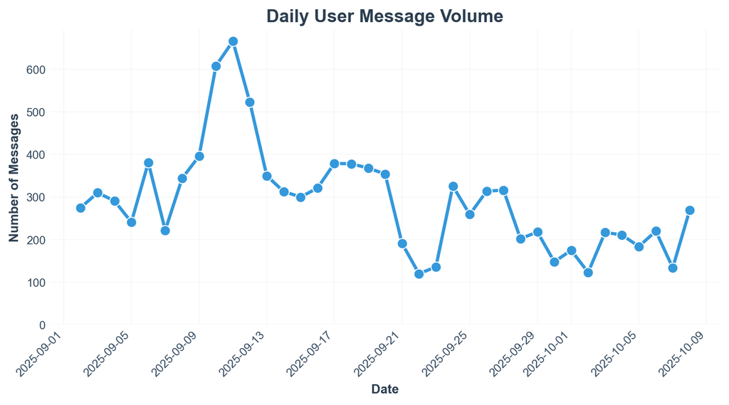

Figure 1: Daily user message volume over time

Daily message volume shows the temporal distribution of student engagement with the AI assistant.

## 1.2 Hourly Distribution

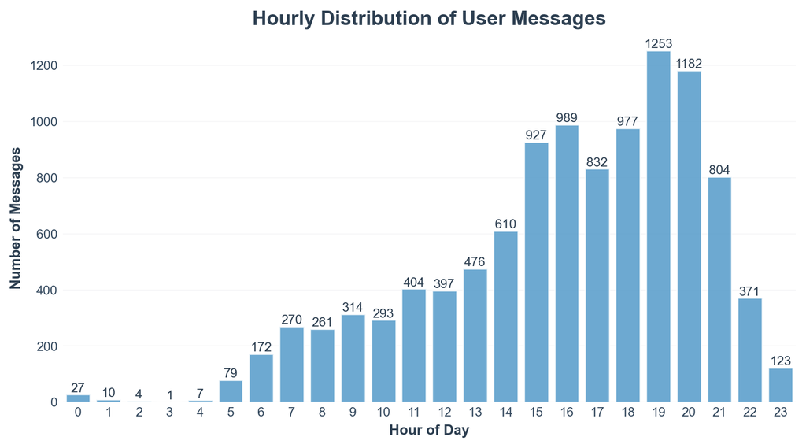

Figure 2: Hourly distribution of user messages throughout the day

This distribution reveals when students are most active in using the platform throughout the day.

## 1.3 Message Statistics

Table 1: Summary statistics for message activity

| role | messages | avg_characters | median_characters | avg_tokens | median_tokens |
| --- | --- | --- | --- | --- | --- |
| user | 10783 | 42.8383 | 38 | 7.84791 | 7 |
| assistant | 7597 | 368.536 | 441 | 57.9879 | 68 |

# Part 2: CAL State Engagement

## 2.1 State Distribution Table

Table 2: CAL State distribution with message counts and percentages

| CAL State | Message Count | Share (%) |
| --- | --- | --- |
| haryana | 6399 | 59.3 |
| Punjab | 3707 | 34.4 |
| MP | 677 | 6.3 |

## 2.2 Top CAL States Visualization

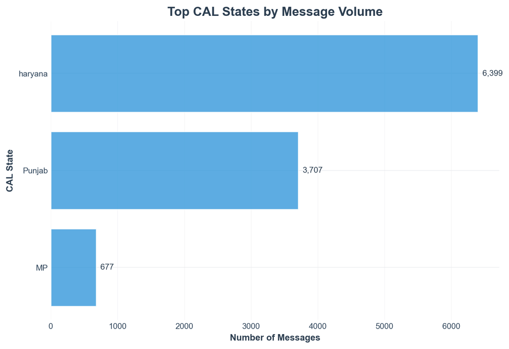

# Part 3: Sentiment Analysis

Sentiment analysis examines the emotional tone of messages exchanged between students and the AI assistant. Understanding sentiment helps assess user satisfaction and the quality of AI responses.

## Understanding Sentiment Analysis

**What is being measured?**

- **User sentiment**: How students feel when interacting with the AI
- **AI sentiment**: Whether the AI maintains an appropriate, supportive tone
- **Interaction quality**: The overall emotional dynamic of conversations

**Technical methodology:**

The model has been fine-tuned on conversational text data to better capture the nuances of educational interactions, including informal language, code snippets, and domain-specific terminology common in learning platforms.

## 3.1 Sentiment Distribution

Table 3: Sentiment distribution by message role

| Role | Sentiment | Count | Percentage (%) |
| --- | --- | --- | --- |
| Assistant | 1 star | 87 | 1.1 |
| Assistant | 2 stars | 41 | 0.5 |
| Assistant | 3 stars | 430 | 5.7 |
| Assistant | 4 stars | 5327 | 70.1 |
| Assistant | 5 stars | 1712 | 22.5 |
| User | 1 star | 2080 | 19.3 |
| User | 2 stars | 297 | 2.8 |
| User | 3 stars | 4088 | 37.9 |
| User | 4 stars | 1202 | 11.1 |
| User | 5 stars | 3116 | 28.9 |

## 3.2 Sentiment Comparison

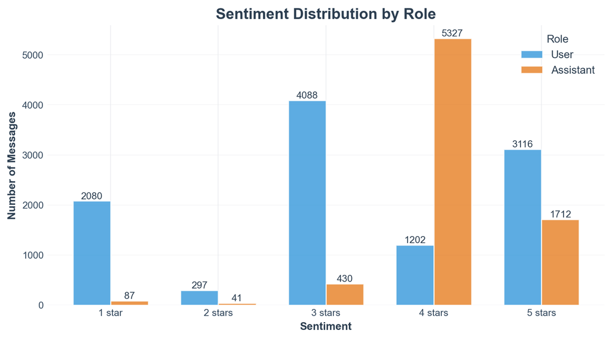

Figure 4: Sentiment distribution comparison between user and AI messages

This comparison reveals whether users and the AI assistant maintain different emotional tones during interactions.

## 3.3 Overall Sentiment Summary

Table 4: Overall sentiment statistics

| role | messages | mean_score | median_score | mean_stars | count_3_stars | count_5_stars | count_1_star | count_4_stars | count_2_stars |
| --- | --- | --- | --- | --- | --- | --- | --- | --- | --- |
| user | 10783 | 0.333073 | 0.303249 | 3.27608 | 4088 | 3116 | 2080 | 1202 | 297 |
| assistant | 7597 | 0.465076 | 0.468567 | 4.1236 | 430 | 1712 | 87 | 5327 | 41 |

# Part 4: Topic Modeling

Topic modeling identifies the main themes and subjects discussed in conversations. This analysis reveals what students talk about most frequently and how the AI responds.

## Understanding Topic Modeling

**What is topic modeling?**

Topic modeling uses natural language processing to automatically discover themes in text data. Each topic is represented by:

- **Keywords**: The most characteristic words for that topic
- **Message count**: How many messages belong to that topic
- **Role**: Whether the topic appears in user or AI messages

This helps identify common student questions, concerns, and the AI’s response patterns.

**Technical methodology:**

The topic modeling is performed using BERTopic, a modern topic modeling technique that leverages transformer embeddings and clustering algorithms:

1. **Text embedding**: Each message is converted into a high-dimensional semantic vector using sentence transformers (SBERT). These embeddings capture the contextual meaning of the text, not just keyword frequency
2. **Dimensionality reduction**: UMAP (Uniform Manifold Approximation and Projection) reduces the embedding dimensions while preserving semantic relationships, making clusters more identifiable
3. **Clustering**: HDBSCAN (Hierarchical Density-Based Spatial Clustering) groups semantically similar messages together based on their embeddings. Unlike traditional methods like LDA, this approach doesn’t require pre-specifying the number of topics
4. **Topic representation**: For each cluster, c-TF-IDF (class-based Term Frequency-Inverse Document Frequency) extracts the most representative keywords that distinguish one topic from others
5. **Role separation**: Topics are analyzed separately for user messages and AI messages to understand the conversation dynamics from both perspectives

This approach provides more coherent and interpretable topics compared to traditional methods, especially for short conversational messages where context is crucial.

## 4.1 User Message Topics

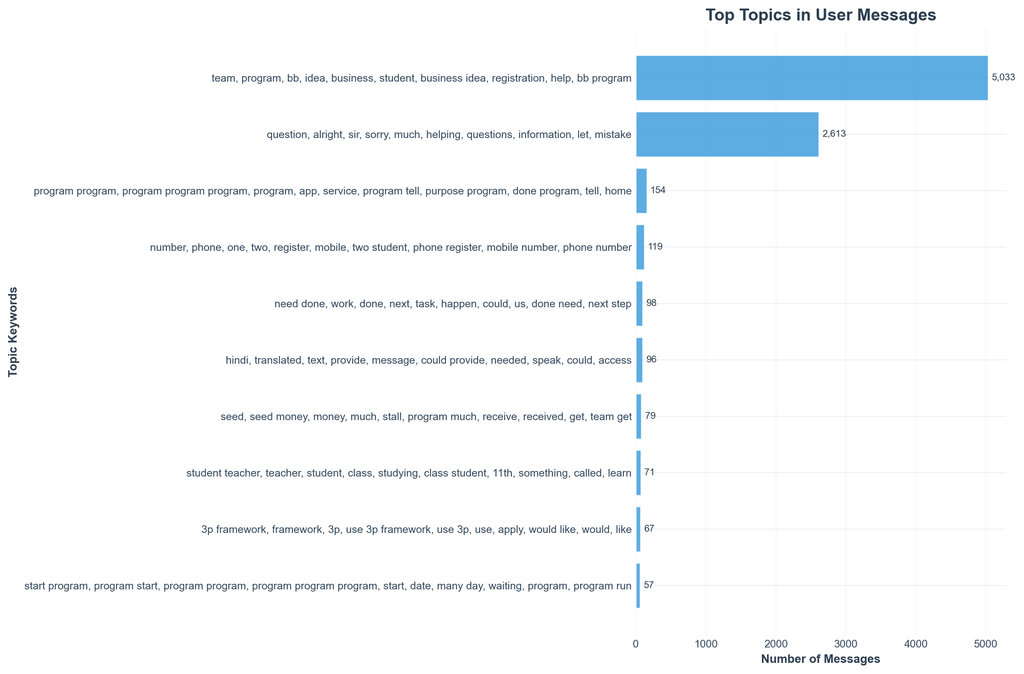

Figure 5: Top 10 topics in user messages

The user topic visualization reveals what students are asking about and discussing most frequently. These topics represent the primary concerns, questions, and areas where students seek assistance from the AI.

## 4.2 AI Message Topics

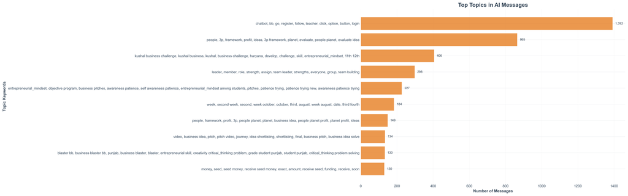

Figure 6: Top 10 topics in AI messages

The AI topic visualization shows the main themes in the assistant’s responses. These topics reflect how the AI is addressing student needs and what types of support it provides most frequently.

## 4.3 Interpreting Topic Patterns

**Understanding User Topics:**

The topics identified in user messages reveal the primary areas where students engage with the platform:

The most prominent user topics suggest the following patterns:

- **Topic 0** (5033 messages): *team, program, bb, idea, business, student, business idea, registration, help, bb program* - Students frequently seek clarification and explanations
- **Topic 1** (2613 messages): *question, alright, sir, sorry, much, helping, questions, information, let, mistake* - Students frequently seek clarification and explanations
- **Topic 2** (154 messages): *program program, program program program, program, app, service, program tell, purpose program, done program, tell, home* - Specific domain-related discussions and inquiries
- **Topic 3** (119 messages): *number, phone, one, two, register, mobile, two student, phone register, mobile number, phone number* - Specific domain-related discussions and inquiries
- **Topic 4** (98 messages): *need done, work, done, next, task, happen, could, us, done need, next step* - Specific domain-related discussions and inquiries

**Understanding AI Topics:**

The topics in AI responses reveal how the assistant supports student learning:

The most prominent AI response topics indicate:

- **Topic 0** (1392 messages): *chatbot, bb, go, register, follow, teacher, click, option, button, login* - Contextual support and domain-specific responses
- **Topic 1** (865 messages): *people, 3p, framework, profit, ideas, 3p framework, planet, evaluate, people planet, evaluate idea* - Contextual support and domain-specific responses
- **Topic 2** (406 messages): *kushal business challenge, kushal business, kushal, business challenge, haryana, develop, challenge, skill, entrepreneurial_mindset, 11th 12th* - Business strategy and entrepreneurial advice
- **Topic 3** (298 messages): *leader, member, role, strength, assign, team leader, strengths, everyone, group, team building* - Contextual support and domain-specific responses
- **Topic 4** (227 messages): *entrepreneurial_mindset, objective program, business pitches, awareness patience, self awareness patience, entrepreneurial_mindset among students, pitches, patience trying, patience trying new, awareness patience trying* - Business strategy and entrepreneurial advice

**Topic Alignment and Pedagogical Insights:**

The relationship between user and AI topics reveals the quality of conversational alignment:

- **Responsive teaching**: When AI topics mirror user topics with added depth, it indicates the assistant is directly addressing student needs
- **Proactive guidance**: Topics in AI messages that extend beyond immediate user questions suggest the assistant is providing broader context and anticipatory support
- **Knowledge gaps**: Frequent topics about basic concepts may indicate areas where students need more foundational instruction or clearer explanations
- **Engagement patterns**: The diversity and specificity of topics reflect how deeply students are engaging with course material

By analyzing these patterns over time, educators can identify which topics require enhanced content, where students struggle most, and how to optimize the AI’s pedagogical approach.

# Summary and Recommendations

## Key Insights

Based on the analysis of student-AI interactions, several important patterns emerge:

**Engagement Patterns**: Students sent 10,783 messages, with peak activity occurring around hour 19.

**Learning States**: The ‘haryana’ state generated the most engagement with 6,399 messages.

**User Sentiment**: Students predominantly express 3 stars sentiment in their interactions.

**Common Topics**: The most frequent discussion topic among students is ‘team, program, bb, idea, business, student, business idea, registration, help, bb program’ with 5033 messages.

## Recommendations

Based on these findings, we recommend the following actions:

1. **Optimize Engagement Timing**
   - Schedule proactive AI interventions during peak usage hours
   - Consider sending reminders or notifications when students are most active
2. **Enhance High-Volume CAL States**
   - Focus development efforts on improving the most-used learning states
   - Add more content and support for popular interaction contexts
3. **Address Sentiment Patterns**
   - Monitor negative sentiment trends and identify root causes
   - Refine AI responses to maintain positive, supportive interactions
4. **Expand Topic Coverage**
   - Create targeted content for frequently discussed topics
   - Develop specialized responses for common student questions
5. **Data Quality and Monitoring**
   - Refresh the dataset regularly by re-running the analysis pipeline
   - Monitor sentiment shifts over time as new cohorts are onboarded
   - Conduct qualitative review of high-volume topics to improve content

## Next Steps

To continue improving the analysis:

- **Update Data**: Re-run the Snakemake pipeline when new data becomes available
- **Deeper Analysis**: Conduct user interviews to validate automated findings
- **A/B Testing**: Experiment with different AI response strategies based on insights
- **Longitudinal Tracking**: Monitor how patterns change over time

**Report generated:** October 19, 2025

**Analysis period:** 2025-09-02T13:59:14 to 2025-10-08T20:13:54

**Total messages analyzed:** 10,783